# Logistic_regression_social

Revanth

2024-04-18

```r
library(ggplot2)
library(cowplot)
library(caret)
library(e1071)
library(pROC)
data <- read.csv("c:/users/admin/desktop/new_data.csv", row.names=1)
data
```

```
##         Instagram_Usage LinkedIn_Usage Snapchat_Usage Twitter_Usage
## masinl             3.50           4.00           1.00          5.00
## peace              7.44           5.12           3.41         12.00
## Patty              3.46           7.00          12.32          0.00
## Bunny              5.23           5.19           1.18          0.00
## tl868              0.00          12.35           0.00         12.40
## drphy              2.20           7.00          12.28          0.00
## trave              5.22           4.00           0.00          0.00
## 19!@s              7.00           4.00           3.00          0.00
## yh2020             8.39          10.00           3.50          0.00
## ds2134            12.10          12.00           0.00          0.00
## ki567              4.35           2.08          12.25          2.25
## ak2001             3.20           2.30          12.20          2.50
## Harvey             5.30           1.52           0.62          0.00
## hahah              6.00           3.00           1.00          1.00
## AKIRA              4.39           3.45           1.25          0.00
## vp1234             7.00           5.00          12.25         12.16
## sss32              9.48          12.48           0.00          0.00
## MVA37@S            6.48           1.55           1.52          0.00
## 2134               5.40           3.55           0.00          0.00
## 15801              3.01           3.57           7.19          0.00
## Baiqi             12.20          12.31           0.00          0.00
##         Whatsapp_Usage Youtube_Usage   OTT Reddit Trouble_falling_asleep
## masinl            1.00          2.50 14.50   2.50                      0
## peace             4.11          4.15 12.00  12.00                      1
## Patty             9.50          1.51  2.00   0.00                      0
## Bunny             5.18          2.00  2.00   0.00                      0
## tl868             3.00          3.30  2.00   1.00                      1
## drphy            12.00          7.00  3.00   0.00                      0
## trave             6.00          3.00  0.00   0.00                      0
## 19!@s            10.00          2.00  3.00   0.00                      1
## yh2020            6.09          4.00  3.00   0.00                      0
## ds2134            1.00          3.00  0.00   0.00                      0
## ki567             1.00          1.00 12.00   0.00                      1
## ak2001            3.40          2.30  1.30   0.00                      0
## Harvey            4.02          0.54  0.51   0.01                      1
## hahah             3.25          2.30  1.00   0.00                      0
## AKIRA             6.30          3.08  1.55   7.00                      0
## vp1234            5.00          5.00  1.00  12.30                      1
## sss32             1.21          3.32  1.41   0.00                      0
```

[output cut: 11 more lines]

```
## trave                   1                          1
## 19!@s                   1                          1
## yh2020                  1                          0
## ds2134                  0                          0
## ki567                   1                          0
## ak2001                  1                          0
## Harvey                  1                          1
## hahah                   1                          0
## AKIRA                   1                          0
## vp1234                  1                          1
## sss32                   1                          0
## MVA37@S                 1                          1
## 2134                    1                          0
## 15801                   1                          0
## Baiqi                   1                          1
```

```r
head(data)
```

```
##        Instagram_Usage LinkedIn_Usage Snapchat_Usage Twitter_Usage
## masinl            3.50           4.00           1.00           5.0
## peace             7.44           5.12           3.41          12.0
## Patty             3.46           7.00          12.32           0.0
## Bunny             5.23           5.19           1.18           0.0
## tl868             0.00          12.35           0.00          12.4
## drphy             2.20           7.00          12.28           0.0
##        Whatsapp_Usage Youtube_Usage  OTT Reddit Trouble_falling_asleep
## masinl           1.00          2.50 14.5    2.5                      0
## peace            4.11          4.15 12.0   12.0                      1
## Patty            9.50          1.51  2.0    0.0                      0
## Bunny            5.18          2.00  2.0    0.0                      0
## tl868            3.00          3.30  2.0    1.0                      1
## drphy           12.00          7.00  3.0    0.0                      0
##        Mood.Productivity Tired.waking.up.in.morning
## masinl                 1                          0
## peace                  1                          0
## Patty                  1                          0
## Bunny                  1                          0
## tl868                  1                          1
## drphy                  1                          0
```

```r
## Data Cleansing and Prep
colnames(data) <- c("Instagram", "LinkedIn", "Snapchat", "Twitter", "Whatsapp", "Youtube", "OTT", "Reddit", "Trouble_sleep", "Mood", "Tired_morning")

head(data)
```

```
##        Instagram LinkedIn Snapchat Twitter Whatsapp Youtube  OTT Reddit
## masinl      3.50     4.00     1.00     5.0     1.00    2.50 14.5    2.5
## peace       7.44     5.12     3.41    12.0     4.11    4.15 12.0   12.0
## Patty       3.46     7.00    12.32     0.0     9.50    1.51  2.0    0.0
## Bunny       5.23     5.19     1.18     0.0     5.18    2.00  2.0    0.0
## tl868       0.00    12.35     0.00    12.4     3.00    3.30  2.0    1.0
## drphy       2.20     7.00    12.28     0.0    12.00    7.00  3.0    0.0
##        Trouble_sleep Mood Tired_morning
## masinl             0    1             0
## peace              1    1             0
## Patty              0    1             0
## Bunny              0    1             0
## tl868              1    1             1
## drphy              0    1             0
```

```r
str(data)
```

```
## 'data.frame':    21 obs. of  11 variables:
##  $ Instagram    : num  3.5 7.44 3.46 5.23 0 2.2 5.22 7 8.39 12.1 ...
##  $ LinkedIn     : num  4 5.12 7 5.19 12.35 ...
##  $ Snapchat     : num  1 3.41 12.32 1.18 0 ...
##  $ Twitter      : num  5 12 0 0 12.4 0 0 0 0 0 ...
##  $ Whatsapp     : num  1 4.11 9.5 5.18 3 12 6 10 6.09 1 ...
##  $ Youtube      : num  2.5 4.15 1.51 2 3.3 7 3 2 4 3 ...
##  $ OTT          : num  14.5 12 2 2 2 3 0 3 3 0 ...
##  $ Reddit       : num  2.5 12 0 0 1 0 0 0 0 0 ...
##  $ Trouble_sleep: int  0 1 0 0 1 0 0 1 0 0 ...
##  $ Mood         : int  1 1 1 1 1 1 1 1 1 0 ...
##  $ Tired_morning: int  0 0 0 0 1 0 1 1 0 0 ...
```

```r
data[data == "?"] <- NA
data$Instagram <- as.factor(data$Instagram)
data$LinkedIn <- as.factor(data$LinkedIn)
data$Snapchat <- as.factor(data$Snapchat)
data$Youtube <- as.factor(data$Youtube)
data$OTT <- as.factor(data$OTT)
data$Reddit <- as.factor(data$Reddit)
data$Trouble_sleep <- as.factor(data$Trouble_sleep)
data$Mood <- as.factor(data$Mood)
data$Tired_morning <- as.factor(data$Tired_morning)

data$Instagram <- as.numeric(as.character(data$Instagram))
data$Instagram <- cut(data$Instagram, breaks = c(-Inf, 6, Inf), labels = c("Less hours", "More hours"))

data$LinkedIn <- as.numeric(as.character(data$LinkedIn))
data$LinkedIn <- cut(data$LinkedIn, breaks = c(-Inf, 6, Inf), labels = c("Less hours", "More hours"))


data$Snapchat <- as.numeric(as.character(data$Snapchat))
data$Snapchat <- cut(data$Snapchat, breaks = c(-Inf, 6, Inf), labels = c("Less hours", "More hours"))


data$Twitter <- as.numeric(as.character(data$Twitter))
data$Twitter <- cut(data$Twitter, breaks = c(-Inf, 4, Inf), labels = c("Less hours", "More hours"))

data$Whatsapp <- as.numeric(as.character(data$Whatsapp))
data$Whatsapp <- cut(data$Whatsapp, breaks = c(-Inf, 6, Inf), labels = c("Less hours", "More hours"))

data$OTT <- as.numeric(as.character(data$OTT))
data$OTT <- cut(data$OTT, breaks = c(-Inf, 6, Inf), labels = c("Less hours", "More hours"))

data$Reddit <- as.numeric(as.character(data$Reddit))
data$Reddit <- cut(data$Reddit, breaks = c(-Inf, 6, Inf), labels = c("Less hours", "More hours"))

data$Youtube <- as.numeric(as.character(data$Youtube))
data$Youtube <- cut(data$Youtube, breaks = c(-Inf, 6, Inf), labels = c("Less hours", "More hours"))

str(data)
```

```
## 'data.frame':    21 obs. of  11 variables:
##  $ Instagram    : Factor w/ 2 levels "Less hours","More hours": 1 2 1 1 1 1 1 2 2 2 ...
##  $ LinkedIn     : Factor w/ 2 levels "Less hours","More hours": 1 1 2 1 2 2 1 1 2 2 ...
##  $ Snapchat     : Factor w/ 2 levels "Less hours","More hours": 1 1 2 1 1 2 1 1 1 1 ...
##  $ Twitter      : Factor w/ 2 levels "Less hours","More hours": 2 2 1 1 2 1 1 1 1 1 ...
##  $ Whatsapp     : Factor w/ 2 levels "Less hours","More hours": 1 1 2 1 1 2 1 2 2 1 ...
##  $ Youtube      : Factor w/ 2 levels "Less hours","More hours": 1 1 1 1 1 2 1 1 1 1 ...
##  $ OTT          : Factor w/ 2 levels "Less hours","More hours": 2 2 1 1 1 1 1 1 1 1 ...
##  $ Reddit       : Factor w/ 2 levels "Less hours","More hours": 1 2 1 1 1 1 1 1 1 1 ...
##  $ Trouble_sleep: Factor w/ 2 levels "0","1": 1 2 1 1 2 1 1 2 1 1 ...
##  $ Mood         : Factor w/ 2 levels "0","1": 2 2 2 2 2 2 2 2 2 1 ...
##  $ Tired_morning: Factor w/ 2 levels "0","1": 1 1 1 1 2 1 2 2 1 1 ...
```

# MODEL DEVELOPMENT

## Logistic Regression Model:

## A logistic regression model is fitted to predict the likelihood of experiencing trouble sleeping based on Twitter usage hours.

```r
## Exploratory Analysis

xtabs(~ Trouble_sleep + Instagram, data=data)
```

```
##              Instagram
## Trouble_sleep Less hours More hours
##             0          9          5
##             1          4          3
```

```r
xtabs(~ Trouble_sleep + LinkedIn, data=data)
```

```
##              LinkedIn
## Trouble_sleep Less hours More hours
##             0          8          6
##             1          6          1
```

```r
xtabs(~ Trouble_sleep + Snapchat, data=data)
```

```
##              Snapchat
## Trouble_sleep Less hours More hours
##             0         11          3
##             1          4          3
```

```r
xtabs(~ Trouble_sleep + Twitter, data=data)
```

```
##              Twitter
## Trouble_sleep Less hours More hours
##             0         13          1
##             1          4          3
```

```r
xtabs(~ Trouble_sleep + Youtube, data=data)
```

```
##              Youtube
## Trouble_sleep Less hours More hours
##             0         12          2
##             1          7          0
```

```r
xtabs(~ Trouble_sleep + OTT, data=data)
```

```
##              OTT
## Trouble_sleep Less hours More hours
##             0         13          1
##             1          4          3
```

```r
xtabs(~ Trouble_sleep + Reddit, data=data)
```

```
##              Reddit
## Trouble_sleep Less hours More hours
##             0         13          1
##             1          5          2
```

```r
logistic_simple <- glm(Trouble_sleep ~ Twitter, data=data, family="binomial")
summary(logistic_simple)
```

```
##
## Call:
## glm(formula = Trouble_sleep ~ Twitter, family = "binomial", data = data)
##
## Coefficients:
##                   Estimate Std. Error z value Pr(>|z|)
## (Intercept)        -1.1787     0.5718  -2.061   0.0393 *
## TwitterMore hours   2.2773     1.2885   1.767   0.0772 .
## ---
## Signif. codes:  0 '***' 0.001 '**' 0.01 '*' 0.05 '.' 0.1 ' ' 1
##
## (Dispersion parameter for binomial family taken to be 1)
##
##     Null deviance: 26.734  on 20  degrees of freedom
## Residual deviance: 23.049  on 19  degrees of freedom
## AIC: 27.049
##
## Number of Fisher Scoring iterations: 4
```

## The coefficient for “TwitterMore hours” (2.2773) suggests an increase in the odds of trouble sleeping with more Twitter usage, although it is not statistically significant at the conventional 0.05 significance level (p-value = 0.0772).

#Model Acceptance

```r
Less_hours.log.odds <- log(4 / 13)
Less_hours.log.odds
```

```
## [1] -1.178655
```

```r
# Now you know how these are calculated
more_hours.log.odds.ratio <- log((3 / 1) / (4/13))
more_hours.log.odds.ratio
```

```
## [1] 2.277267
```

## The coefficient for “TwitterMore hours” indicates the change in log-odds of experiencing trouble sleeping when Twitter usage increases to “More hours”. The estimate is 2.2773 with a standard error of 1.2885. While the coefficient is positive, suggesting an increase in the odds of trouble sleeping with more Twitter usage, it is not statistically significant at the conventional 0.05 significance level (p-value = 0.0772).

# Prediction

```r
predicted.data <- data.frame(probability.of.hd=logistic_simple$fitted.values,Twitter=data$Twitter)
predicted.data
```

```
##         probability.of.hd    Twitter
## masinl          0.7500000 More hours
## peace           0.7500000 More hours
## Patty           0.2352941 Less hours
## Bunny           0.2352941 Less hours
## tl868           0.7500000 More hours
## drphy           0.2352941 Less hours
## trave           0.2352941 Less hours
## 19!@s           0.2352941 Less hours
## yh2020          0.2352941 Less hours
## ds2134          0.2352941 Less hours
## ki567           0.2352941 Less hours
## ak2001          0.2352941 Less hours
## Harvey          0.2352941 Less hours
## hahah           0.2352941 Less hours
## AKIRA           0.2352941 Less hours
## vp1234          0.7500000 More hours
## sss32           0.2352941 Less hours
## MVA37@S         0.2352941 Less hours
## 2134            0.2352941 Less hours
## 15801           0.2352941 Less hours
## Baiqi           0.2352941 Less hours
```

```r
xtabs(~ probability.of.hd + Twitter, data=predicted.data)
```

```
##                    Twitter
## probability.of.hd   Less hours More hours
##   0.235294117647479         17          0
##   0.749999999999444          0          4
```

```r
logistic <- glm(Trouble_sleep ~ ., data=data, family="binomial")
summary(logistic)
```

```
##
## Call:
## glm(formula = Trouble_sleep ~ ., family = "binomial", data = data)
##
## Coefficients:
##                      Estimate Std. Error z value Pr(>|z|)
## (Intercept)             35.61   93977.69   0.000    1.000
## InstagramMore hours    -18.38   40296.95   0.000    1.000
## LinkedInMore hours     -40.80   23010.71  -0.002    0.999
## SnapchatMore hours     103.22   38482.35   0.003    0.998
## TwitterMore hours       61.35   29051.05   0.002    0.998
## WhatsappMore hours      38.84   43662.86   0.001    0.999
## YoutubeMore hours      -42.97   49841.17  -0.001    0.999
## OTTMore hours           41.97   26021.51   0.002    0.999
## RedditMore hours        61.30   51233.57   0.001    0.999
## Mood1                 -159.55  113933.94  -0.001    0.999
## Tired_morning1         123.94   43021.95   0.003    0.998
##
## (Dispersion parameter for binomial family taken to be 1)
##
##     Null deviance: 26.7336  on 20  degrees of freedom
## Residual deviance:  2.7726  on 10  degrees of freedom
## AIC: 24.773
##
## Number of Fisher Scoring iterations: 22
```

## INSIGHTS :

## The predicted.data dataframe shows the predicted probabilities of experiencing trouble sleeping for each individual, along with their corresponding Twitter usage category. For example:

## Individuals with usernames “masinl”, “peace”, and “tl868” who spend more hours on Twitter have predicted probabilities of 0.75.

## Individuals with usernames “Patty” and “Bunny” who spend less hours on Twitter have predicted probabilities of 0.235.

# RESIDUAL ANALYSIS

```r
## Now calculate the overall "Pseudo R-squared" and its p-value
ll.null <- logistic$null.deviance/-2
ll.proposed <- logistic$deviance/-2
(ll.null - ll.proposed) / ll.null
```

```
## [1] 0.8962882
```

```r
## The p-value for the R^2
1 - pchisq(2*(ll.proposed - ll.null), df=(length(logistic$coefficients)-1))
```

```
## [1] 0.007704567
```

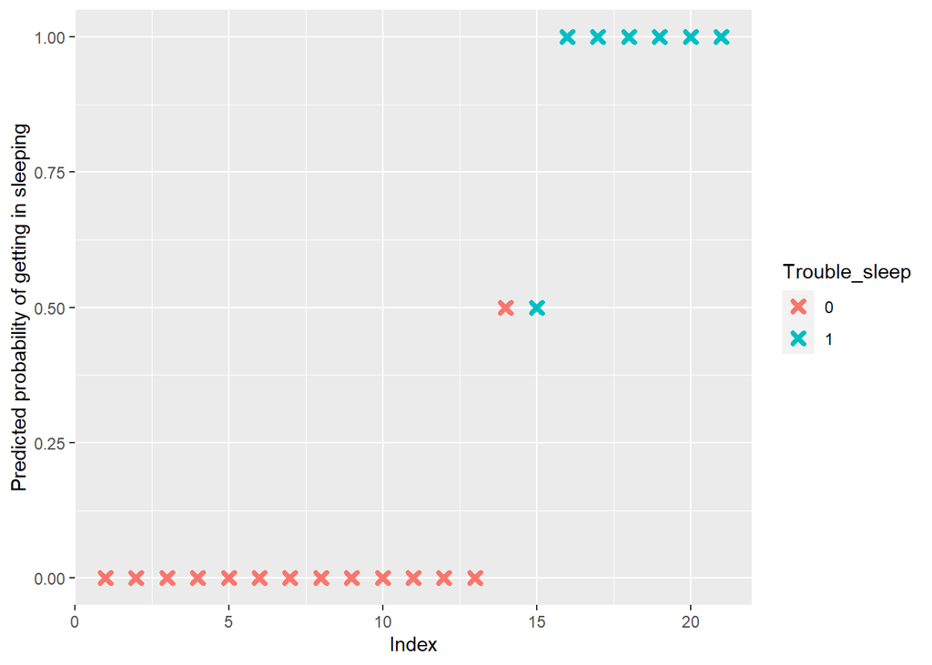

```r
predicted.data <- data.frame(probability.of.hd=logistic$fitted.values,Trouble_sleep=data$Trouble_sleep)
predicted.data <- predicted.data[order(predicted.data$probability.of.hd, decreasing=FALSE),]
predicted.data$rank <- 1:nrow(predicted.data)

ggplot(data=predicted.data, aes(x=rank, y=probability.of.hd)) +
  geom_point(aes(color=Trouble_sleep), alpha=1, shape=4, stroke=2) +
  xlab("Index") +
  ylab("Predicted probability of getting in sleeping")
```

## Insights : The pseudo R-squared value is calculated to evaluate the goodness of fit of the logistic regression model.

## The calculated value is approximately 0.8963, indicating that the model explains about 89.63% of the variance in the response variable.

## The p-value associated with the pseudo R-squared is 0.0077, which suggests that the model is statistically significant in explaining the variance in the response variable.

```r
# From Caret
pdata <- predict(logistic,newdata=data,type="response" )
pdata
```

```
##       masinl        peace        Patty        Bunny        tl868        drphy
## 1.116409e-09 1.000000e+00 1.431765e-10 2.220446e-16 1.000000e+00 2.220446e-16
##        trave        19!@s       yh2020       ds2134        ki567       ak2001
## 5.000000e-01 1.000000e+00 2.220446e-16 5.826215e-11 1.000000e+00 1.012457e-09
##       Harvey        hahah        AKIRA       vp1234        sss32      MVA37@S
## 5.000000e-01 2.220446e-16 4.650672e-11 1.000000e+00 2.220446e-16 1.671010e-10
##         2134        15801        Baiqi
## 2.220446e-16 1.000000e+00 1.472510e-09
```

```r
data$Trouble_sleep
```

```
##  [1] 0 1 0 0 1 0 0 1 0 0 1 0 1 0 0 1 0 0 0 1 0
## Levels: 0 1
```

```r
pdataF <- as.factor(ifelse(test=as.numeric(pdata>0.5) == 0, yes="0", no="1"))
```

## Insights:

## Predicted probabilities are converted into factors (pdataF) by comparing them with a threshold of 0.5, where values above 0.5 are classified as 1 (indicating trouble sleeping) and values below 0.5 are classified as 0 (indicating no trouble sleeping).

#MODEL ACCURACY

```r
confusionMatrix(pdataF, data$Trouble_sleep)
```

[output not shown]

```r
# From pROC
roc(data$Trouble_sleep,logistic$fitted.values,plot=TRUE)
```

```
##
## Call:
## roc.default(response = data$Trouble_sleep, predictor = logistic$fitted.values,     plot = TRUE)
##
## Data: logistic$fitted.values in 14 controls (data$Trouble_sleep 0) < 7 cases (data$Trouble_sleep 1).
## Area under the curve: 0.9949
```

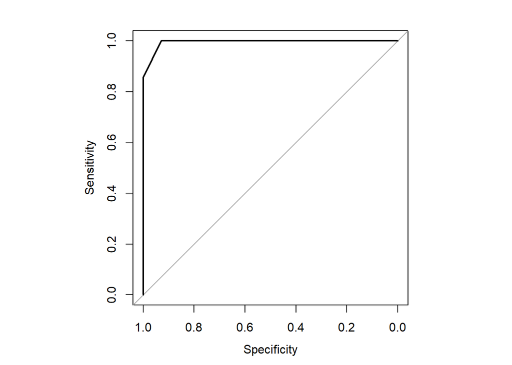

```
##
## Call:
## roc.default(response = data$Trouble_sleep, predictor = logistic$fitted.values,     plot = TRUE)
##
## Data: logistic$fitted.values in 14 controls (data$Trouble_sleep 0) < 7 cases (data$Trouble_sleep 1).
## Area under the curve: 0.9949
```

```r
par(pty = "s")
roc(data$Trouble_sleep,logistic$fitted.values,plot=TRUE)
```

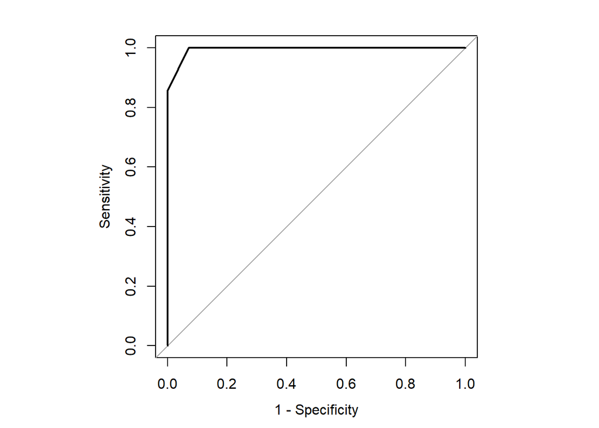

```
##
## Call:
## roc.default(response = data$Trouble_sleep, predictor = logistic$fitted.values,     plot = TRUE, legacy.axes = TRUE)
##
## Data: logistic$fitted.values in 14 controls (data$Trouble_sleep 0) < 7 cases (data$Trouble_sleep 1).
## Area under the curve: 0.9949
```

```r
roc(data$Trouble_sleep,logistic$fitted.values,plot=TRUE, legacy.axes=TRUE)
```

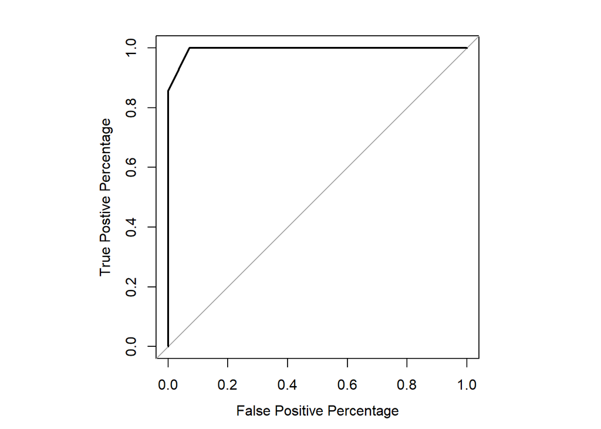

```
##
## Call:
## roc.default(response = data$Trouble_sleep, predictor = logistic$fitted.values,     plot = TRUE, legacy.axes = TRUE, xlab = "False Positive Percentage",     ylab = "True Postive Percentage")
##
## Data: logistic$fitted.values in 14 controls (data$Trouble_sleep 0) < 7 cases (data$Trouble_sleep 1).
## Area under the curve: 0.9949
```

```r
roc(data$Trouble_sleep,logistic$fitted.values,plot=TRUE, legacy.axes=TRUE, xlab="False Positive Percentage", ylab="True Postive Percentage")
```

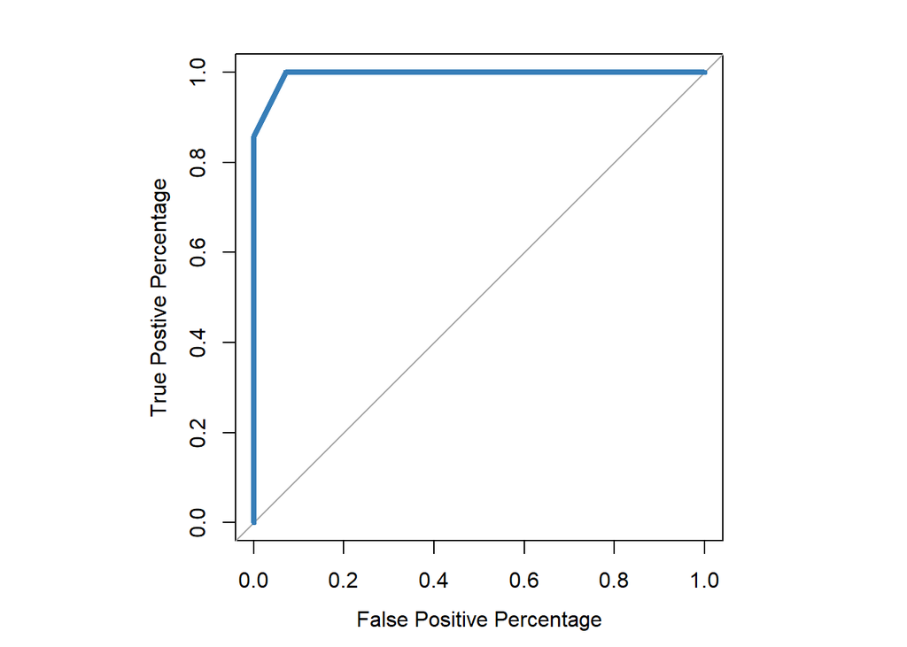

```
##
## Call:
## roc.default(response = data$Trouble_sleep, predictor = logistic$fitted.values,     plot = TRUE, legacy.axes = TRUE, xlab = "False Positive Percentage",     ylab = "True Postive Percentage", col = "#377eb8", lwd = 4)
##
## Data: logistic$fitted.values in 14 controls (data$Trouble_sleep 0) < 7 cases (data$Trouble_sleep 1).
## Area under the curve: 0.9949
```

```r
roc(data$Trouble_sleep,logistic$fitted.values,plot=TRUE, legacy.axes=TRUE, xlab="False Positive Percentage", ylab="True Postive Percentage", col="#377eb8", lwd=4)
```

```r
roc(data$Trouble_sleep,logistic$fitted.values,plot=TRUE, legacy.axes=TRUE, xlab="False Positive Percentage", ylab="True Postive Percentage", col="#377eb8", lwd=4)
```

```
##
## Call:
## roc.default(response = data$Trouble_sleep, predictor = logistic$fitted.values,     plot = TRUE, legacy.axes = TRUE, xlab = "False Positive Percentage",     ylab = "True Postive Percentage", col = "#377eb8", lwd = 4)
##
## Data: logistic$fitted.values in 14 controls (data$Trouble_sleep 0) < 7 cases (data$Trouble_sleep 1).
## Area under the curve: 0.9949
```

```r
roc.info <- roc(data$Trouble_sleep, logistic$fitted.values, legacy.axes=TRUE)
str(roc.info)
```

```
## List of 15
##  $ percent           : logi FALSE
##  $ sensitivities     : num [1:15] 1 1 1 1 1 ...
##  $ specificities     : num [1:15] 0 0.429 0.5 0.571 0.643 ...
##  $ thresholds        : num [1:15] -Inf 2.33e-11 5.24e-11 1.01e-10 1.55e-10 ...
##  $ direction         : chr "<"
##  $ cases             : Named num [1:7] 1 1 1 1 0.5 ...
##   ..- attr(*, "names")= chr [1:7] "peace" "tl868" "19!@s" "ki567" ...
##  $ controls          : Named num [1:14] 1.12e-09 1.43e-10 2.22e-16 2.22e-16 5.00e-01 ...
##   ..- attr(*, "names")= chr [1:14] "masinl" "Patty" "Bunny" "drphy" ...
##  $ fun.sesp          :function (thresholds, controls, cases, direction)
##  $ auc               : 'auc' num 0.995
##   ..- attr(*, "partial.auc")= logi FALSE
##   ..- attr(*, "percent")= logi FALSE
##   ..- attr(*, "roc")=List of 15
##   .. ..$ percent           : logi FALSE
##   .. ..$ sensitivities     : num [1:15] 1 1 1 1 1 ...
##   .. ..$ specificities     : num [1:15] 0 0.429 0.5 0.571 0.643 ...
##   .. ..$ thresholds        : num [1:15] -Inf 2.33e-11 5.24e-11 1.01e-10 1.55e-10 ...
##   .. ..$ direction         : chr "<"
##   .. ..$ cases             : Named num [1:7] 1 1 1 1 0.5 ...
##   .. .. ..- attr(*, "names")= chr [1:7] "peace" "tl868" "19!@s" "ki567" ...
##   .. ..$ controls          : Named num [1:14] 1.12e-09 1.43e-10 2.22e-16 2.22e-16 5.00e-01 ...
##   .. .. ..- attr(*, "names")= chr [1:14] "masinl" "Patty" "Bunny" "drphy" ...
##   .. ..$ fun.sesp          :function (thresholds, controls, cases, direction)
##   .. ..$ auc               : 'auc' num 0.995
##   .. .. ..- attr(*, "partial.auc")= logi FALSE
##   .. .. ..- attr(*, "percent")= logi FALSE
##   .. .. ..- attr(*, "roc")=List of 8
##   .. .. .. ..$ percent      : logi FALSE
##   .. .. .. ..$ sensitivities: num [1:15] 1 1 1 1 1 ...
##   .. .. .. ..$ specificities: num [1:15] 0 0.429 0.5 0.571 0.643 ...
##   .. .. .. ..$ thresholds   : num [1:15] -Inf 2.33e-11 5.24e-11 1.01e-10 1.55e-10 ...
##   .. .. .. ..$ direction    : chr "<"
##   .. .. .. ..$ cases        : Named num [1:7] 1 1 1 1 0.5 ...
##   .. .. .. .. ..- attr(*, "names")= chr [1:7] "peace" "tl868" "19!@s" "ki567" ...
##   .. .. .. ..$ controls     : Named num [1:14] 1.12e-09 1.43e-10 2.22e-16 2.22e-16 5.00e-01 ...
##   .. .. .. .. ..- attr(*, "names")= chr [1:14] "masinl" "Patty" "Bunny" "drphy" ...
##   .. .. .. ..$ fun.sesp     :function (thresholds, controls, cases, direction)
##   .. .. .. ..- attr(*, "class")= chr "roc"
##   .. ..$ call              : language roc.default(response = data$Trouble_sleep, predictor = logistic$fitted.values,      legacy.axes = TRUE)
##   .. ..$ original.predictor: Named num [1:21] 1.12e-09 1.00 1.43e-10 2.22e-16 1.00 ...
##   .. .. ..- attr(*, "names")= chr [1:21] "masinl" "peace" "Patty" "Bunny" ...
##   .. ..$ original.response : Factor w/ 2 levels "0","1": 1 2 1 1 2 1 1 2 1 1 ...
##   .. ..$ predictor         : Named num [1:21] 1.12e-09 1.00 1.43e-10 2.22e-16 1.00 ...
##   .. .. ..- attr(*, "names")= chr [1:21] "masinl" "peace" "Patty" "Bunny" ...
##   .. ..$ response          : Factor w/ 2 levels "0","1": 1 2 1 1 2 1 1 2 1 1 ...
##   .. ..$ levels            : chr [1:2] "0" "1"
##   .. ..- attr(*, "class")= chr "roc"
##  $ call              : language roc.default(response = data$Trouble_sleep, predictor = logistic$fitted.values,      legacy.axes = TRUE)
##  $ original.predictor: Named num [1:21] 1.12e-09 1.00 1.43e-10 2.22e-16 1.00 ...
##   ..- attr(*, "names")= chr [1:21] "masinl" "peace" "Patty" "Bunny" ...
##  $ original.response : Factor w/ 2 levels "0","1": 1 2 1 1 2 1 1 2 1 1 ...
##  $ predictor         : Named num [1:21] 1.12e-09 1.00 1.43e-10 2.22e-16 1.00 ...
##   ..- attr(*, "names")= chr [1:21] "masinl" "peace" "Patty" "Bunny" ...
##  $ response          : Factor w/ 2 levels "0","1": 1 2 1 1 2 1 1 2 1 1 ...
##  $ levels            : chr [1:2] "0" "1"
##  - attr(*, "class")= chr "roc"
```

```r
## tpp = true positive percentage
## fpp = false positive precentage
roc.df <- data.frame(tpp=roc.info$sensitivities*100, fpp=(1 - roc.info$specificities)*100,thresholds=roc.info$thresholds)
roc.df
```

```
##          tpp        fpp   thresholds
## 1  100.00000 100.000000         -Inf
## 2  100.00000  57.142857 2.325347e-11
## 3  100.00000  50.000000 5.238443e-11
## 4  100.00000  42.857143 1.007193e-10
## 5  100.00000  35.714286 1.551387e-10
## 6  100.00000  28.571429 5.897791e-10
## 7  100.00000  21.428571 1.064433e-09
## 8  100.00000  14.285714 1.294459e-09
## 9  100.00000   7.142857 2.500000e-01
## 10  85.71429   0.000000 7.500000e-01
## 11  71.42857   0.000000 1.000000e+00
## 12  57.14286   0.000000 1.000000e+00
## 13  28.57143   0.000000 1.000000e+00
## 14  14.28571   0.000000 1.000000e+00
## 15   0.00000   0.000000          Inf
```

```r
head(roc.df)
```

```
##   tpp       fpp   thresholds
## 1 100 100.00000         -Inf
## 2 100  57.14286 2.325347e-11
## 3 100  50.00000 5.238443e-11
## 4 100  42.85714 1.007193e-10
## 5 100  35.71429 1.551387e-10
## 6 100  28.57143 5.897791e-10
```

## Insights : Accuracy: The overall accuracy of the model is approximately 95.24%, indicating that the model correctly predicts trouble sleeping status for 95.24% of the observations.

## The area under the ROC curve (AUC) is a measure of the model’s ability to discriminate between positive and negative cases. In this case, the AUC is approximately 0.9949, indicating high discrimination ability.

## The ROC curve illustrates how the model’s sensitivity and specificity vary with different threshold values for classifying observations.

```r
tail(roc.df)
```

```
##         tpp fpp thresholds
## 10 85.71429   0       0.75
## 11 71.42857   0       1.00
## 12 57.14286   0       1.00
## 13 28.57143   0       1.00
## 14 14.28571   0       1.00
## 15  0.00000   0        Inf
```

```r
roc.df[roc.df$tpp > 60 & roc.df$tpp < 80,]
```

```
##         tpp fpp thresholds
## 11 71.42857   0          1
```

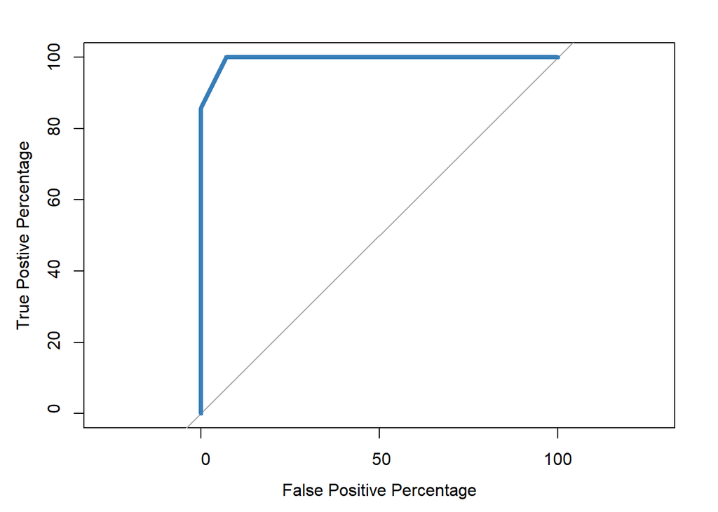

```
##
## Call:
## roc.default(response = data$Trouble_sleep, predictor = logistic$fitted.values,     percent = TRUE, plot = TRUE, legacy.axes = TRUE, xlab = "False Positive Percentage",     ylab = "True Postive Percentage", col = "#377eb8", lwd = 4)
##
## Data: logistic$fitted.values in 14 controls (data$Trouble_sleep 0) < 7 cases (data$Trouble_sleep 1).
## Area under the curve: 99.49%
```

```r
roc(data$Trouble_sleep,logistic$fitted.values,plot=TRUE, legacy.axes=TRUE, xlab="False Positive Percentage", ylab="True Postive Percentage", col="#377eb8", lwd=4, percent=TRUE)
```

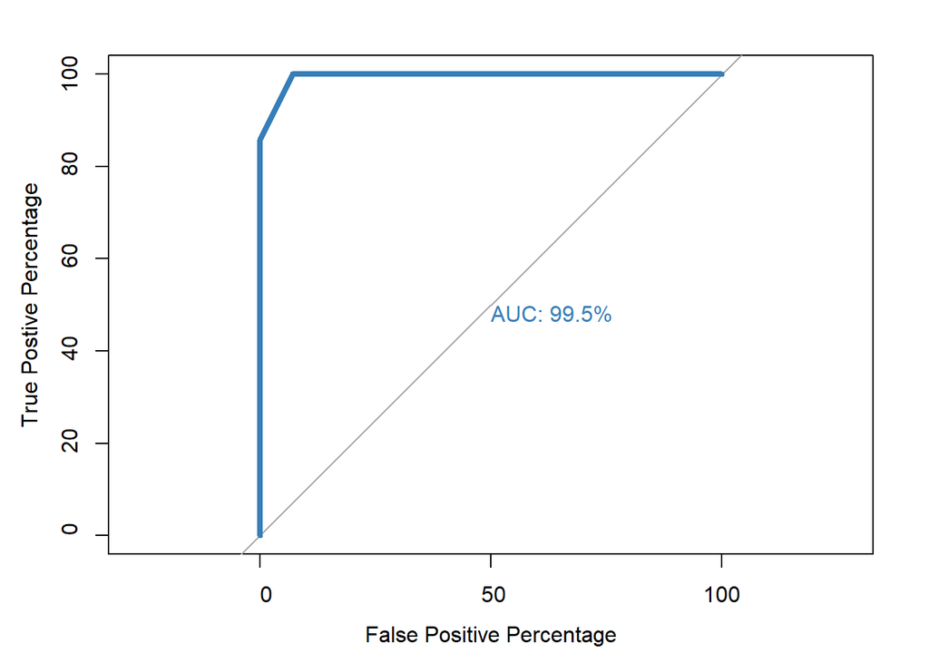

```
##
## Call:
## roc.default(response = data$Trouble_sleep, predictor = logistic$fitted.values,     percent = TRUE, plot = TRUE, legacy.axes = TRUE, xlab = "False Positive Percentage",     ylab = "True Postive Percentage", col = "#377eb8", lwd = 4,     print.auc = TRUE)
##
## Data: logistic$fitted.values in 14 controls (data$Trouble_sleep 0) < 7 cases (data$Trouble_sleep 1).
## Area under the curve: 99.49%
```

```r
roc(data$Trouble_sleep,logistic$fitted.values,plot=TRUE, legacy.axes=TRUE, xlab="False Positive Percentage", ylab="True Postive Percentage", col="#377eb8", lwd=4, percent=TRUE, print.auc=TRUE)
```

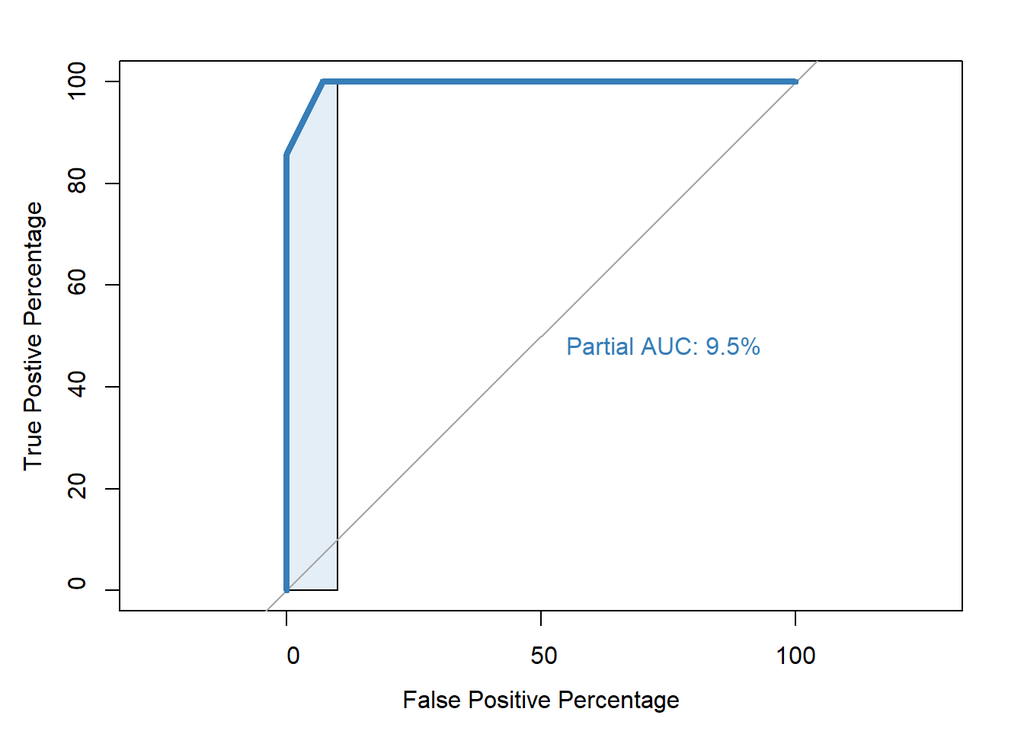

```
##
## Call:
## roc.default(response = data$Trouble_sleep, predictor = logistic$fitted.values,     percent = TRUE, plot = TRUE, legacy.axes = TRUE, xlab = "False Positive Percentage",     ylab = "True Postive Percentage", col = "#377eb8", lwd = 4,     print.auc = TRUE, partial.auc = c(100, 90), auc.polygon = TRU…
##
## Data: logistic$fitted.values in 14 controls (data$Trouble_sleep 0) < 7 cases (data$Trouble_sleep 1).
## Partial area under the curve (specificity 100%-90%): 9.49%
```

```r
roc(data$Trouble_sleep,logistic$fitted.values,plot=TRUE, legacy.axes=TRUE, xlab="False Positive Percentage", ylab="True Postive Percentage", col="#377eb8", lwd=4, percent=TRUE, print.auc=TRUE, partial.auc=c(100, 90), auc.polygon = TRUE, auc.polygon.col = "#377eb822", print.auc.x=45)
```

```r
# Lets do two roc plots to understand which model is better
roc(data$Trouble_sleep, logistic_simple$fitted.values, plot=TRUE, legacy.axes=TRUE, percent=TRUE, xlab="False Positive Percentage", ylab="True Postive Percentage", col="#377eb8", lwd=4, print.auc=TRUE)
```

```
##
## Call:
## roc.default(response = data$Trouble_sleep, predictor = logistic_simple$fitted.values,     percent = TRUE, plot = TRUE, legacy.axes = TRUE, xlab = "False Positive Percentage",     ylab = "True Postive Percentage", col = "#377eb8", lwd = 4,     print.auc = TRUE)
##
## Data: logistic_simple$fitted.values in 14 controls (data$Trouble_sleep 0) < 7 cases (data$Trouble_sleep 1).
## Area under the curve: 67.86%
```

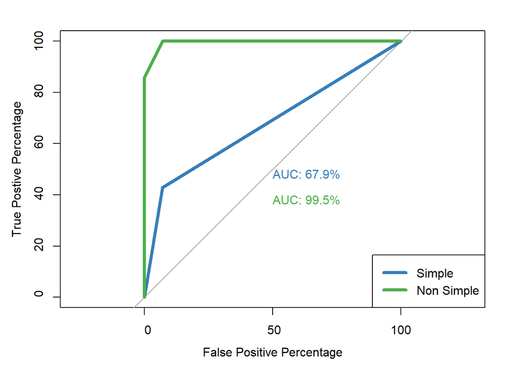

```r
# Lets add the other graph
plot.roc(data$Trouble_sleep, logistic$fitted.values, percent=TRUE, col="#4daf4a", lwd=4, print.auc=TRUE, add=TRUE, print.auc.y=40)
legend("bottomright", legend=c("Simple", "Non Simple"), col=c("#377eb8", "#4daf4a"), lwd=4)
```